# Risk Factor Analysis

## Outcome Variable

**Outcome Variable:** ever_swasted

## Predictor Variables

**Intervention Variable:** brthmon

**Adjustment Set:**

unadjusted

## Stratifying Variables

The analysis was stratified on these variable(s):

- agecat
- studyid
- country

## Data Summary

| agecat | studyid | country | brthmon | ever_swasted | n_cell | n |
| --- | --- | --- | --- | --- | --- | --- |
| 0-24 months | ki0047075b-MAL-ED | BANGLADESH | 1 | 0 | 21 | 263 |
| 0-24 months | ki0047075b-MAL-ED | BANGLADESH | 1 | 1 | 0 | 263 |
| 0-24 months | ki0047075b-MAL-ED | BANGLADESH | 2 | 0 | 24 | 263 |
| 0-24 months | ki0047075b-MAL-ED | BANGLADESH | 2 | 1 | 1 | 263 |
| 0-24 months | ki0047075b-MAL-ED | BANGLADESH | 3 | 0 | 19 | 263 |
| 0-24 months | ki0047075b-MAL-ED | BANGLADESH | 3 | 1 | 5 | 263 |
| 0-24 months | ki0047075b-MAL-ED | BANGLADESH | 4 | 0 | 19 | 263 |
| 0-24 months | ki0047075b-MAL-ED | BANGLADESH | 4 | 1 | 3 | 263 |
| 0-24 months | ki0047075b-MAL-ED | BANGLADESH | 5 | 0 | 20 | 263 |
| 0-24 months | ki0047075b-MAL-ED | BANGLADESH | 5 | 1 | 2 | 263 |
| 0-24 months | ki0047075b-MAL-ED | BANGLADESH | 6 | 0 | 11 | 263 |
| 0-24 months | ki0047075b-MAL-ED | BANGLADESH | 6 | 1 | 0 | 263 |
| 0-24 months | ki0047075b-MAL-ED | BANGLADESH | 7 | 0 | 19 | 263 |
| 0-24 months | ki0047075b-MAL-ED | BANGLADESH | 7 | 1 | 1 | 263 |
| 0-24 months | ki0047075b-MAL-ED | BANGLADESH | 8 | 0 | 25 | 263 |
| 0-24 months | ki0047075b-MAL-ED | BANGLADESH | 8 | 1 | 1 | 263 |
| 0-24 months | ki0047075b-MAL-ED | BANGLADESH | 9 | 0 | 21 | 263 |
| 0-24 months | ki0047075b-MAL-ED | BANGLADESH | 9 | 1 | 2 | 263 |
| 0-24 months | ki0047075b-MAL-ED | BANGLADESH | 10 | 0 | 21 | 263 |
| 0-24 months | ki0047075b-MAL-ED | BANGLADESH | 10 | 1 | 3 | 263 |
| 0-24 months | ki0047075b-MAL-ED | BANGLADESH | 11 | 0 | 17 | 263 |
| 0-24 months | ki0047075b-MAL-ED | BANGLADESH | 11 | 1 | 0 | 263 |
| 0-24 months | ki0047075b-MAL-ED | BANGLADESH | 12 | 0 | 25 | 263 |
| 0-24 months | ki0047075b-MAL-ED | BANGLADESH | 12 | 1 | 3 | 263 |
| 0-24 months | ki0047075b-MAL-ED | BRAZIL | 1 | 0 | 15 | 233 |
| 0-24 months | ki0047075b-MAL-ED | BRAZIL | 1 | 1 | 0 | 233 |
| 0-24 months | ki0047075b-MAL-ED | BRAZIL | 2 | 0 | 25 | 233 |
| 0-24 months | ki0047075b-MAL-ED | BRAZIL | 2 | 1 | 0 | 233 |
| 0-24 months | ki0047075b-MAL-ED | BRAZIL | 3 | 0 | 20 | 233 |
| 0-24 months | ki0047075b-MAL-ED | BRAZIL | 3 | 1 | 0 | 233 |

[output cut: 2034 more lines]

The following strata were considered:

- agecat: 0-24 months, studyid: ki0047075b-MAL-ED, country: BANGLADESH
- agecat: 0-24 months, studyid: ki0047075b-MAL-ED, country: BRAZIL
- agecat: 0-24 months, studyid: ki0047075b-MAL-ED, country: INDIA
- agecat: 0-24 months, studyid: ki0047075b-MAL-ED, country: NEPAL
- agecat: 0-24 months, studyid: ki0047075b-MAL-ED, country: PERU
- agecat: 0-24 months, studyid: ki0047075b-MAL-ED, country: SOUTH AFRICA
- agecat: 0-24 months, studyid: ki0047075b-MAL-ED, country: TANZANIA, UNITED REPUBLIC OF
- agecat: 0-24 months, studyid: ki1000108-CMC-V-BCS-2002, country: INDIA
- agecat: 0-24 months, studyid: ki1000108-IRC, country: INDIA
- agecat: 0-24 months, studyid: ki1000109-EE, country: PAKISTAN
- agecat: 0-24 months, studyid: ki1000109-ResPak, country: PAKISTAN
- agecat: 0-24 months, studyid: ki1000304b-SAS-CompFeed, country: INDIA
- agecat: 0-24 months, studyid: ki1000304b-SAS-FoodSuppl, country: INDIA
- agecat: 0-24 months, studyid: ki1017093-NIH-Birth, country: BANGLADESH
- agecat: 0-24 months, studyid: ki1066203-TanzaniaChild2, country: TANZANIA, UNITED REPUBLIC OF
- agecat: 0-24 months, studyid: ki1101329-Keneba, country: GAMBIA
- agecat: 0-24 months, studyid: ki1112895-Guatemala BSC, country: GUATEMALA
- agecat: 0-24 months, studyid: ki1112895-iLiNS-Zinc, country: BURKINA FASO
- agecat: 0-24 months, studyid: ki1113344-GMS-Nepal, country: NEPAL
- agecat: 0-24 months, studyid: ki1114097-CMIN, country: BANGLADESH
- agecat: 0-24 months, studyid: ki1114097-CMIN, country: BRAZIL
- agecat: 0-24 months, studyid: ki1114097-CMIN, country: GUINEA-BISSAU
- agecat: 0-24 months, studyid: ki1114097-CMIN, country: PERU
- agecat: 0-24 months, studyid: ki1114097-CONTENT, country: PERU
- agecat: 0-24 months, studyid: ki1119695-PROBIT, country: BELARUS
- agecat: 0-24 months, studyid: ki1126311-ZVITAMBO, country: ZIMBABWE
- agecat: 0-24 months, studyid: ki1148112-LCNI-5, country: MALAWI
- agecat: 0-24 months, studyid: kiGH5241-JiVitA-3, country: BANGLADESH
- agecat: 0-24 months, studyid: kiGH5241-JiVitA-4, country: BANGLADESH
- agecat: 0-6 months, studyid: ki0047075b-MAL-ED, country: BANGLADESH
- agecat: 0-6 months, studyid: ki0047075b-MAL-ED, country: BRAZIL
- agecat: 0-6 months, studyid: ki0047075b-MAL-ED, country: INDIA
- agecat: 0-6 months, studyid: ki0047075b-MAL-ED, country: NEPAL
- agecat: 0-6 months, studyid: ki0047075b-MAL-ED, country: PERU
- agecat: 0-6 months, studyid: ki0047075b-MAL-ED, country: SOUTH AFRICA
- agecat: 0-6 months, studyid: ki0047075b-MAL-ED, country: TANZANIA, UNITED REPUBLIC OF
- agecat: 0-6 months, studyid: ki1000108-CMC-V-BCS-2002, country: INDIA
- agecat: 0-6 months, studyid: ki1000108-IRC, country: INDIA
- agecat: 0-6 months, studyid: ki1000109-EE, country: PAKISTAN
- agecat: 0-6 months, studyid: ki1000109-ResPak, country: PAKISTAN
- agecat: 0-6 months, studyid: ki1000304b-SAS-CompFeed, country: INDIA
- agecat: 0-6 months, studyid: ki1000304b-SAS-FoodSuppl, country: INDIA
- agecat: 0-6 months, studyid: ki1017093-NIH-Birth, country: BANGLADESH
- agecat: 0-6 months, studyid: ki1066203-TanzaniaChild2, country: TANZANIA, UNITED REPUBLIC OF
- agecat: 0-6 months, studyid: ki1101329-Keneba, country: GAMBIA
- agecat: 0-6 months, studyid: ki1112895-Guatemala BSC, country: GUATEMALA
- agecat: 0-6 months, studyid: ki1113344-GMS-Nepal, country: NEPAL
- agecat: 0-6 months, studyid: ki1114097-CMIN, country: BANGLADESH
- agecat: 0-6 months, studyid: ki1114097-CMIN, country: BRAZIL
- agecat: 0-6 months, studyid: ki1114097-CMIN, country: GUINEA-BISSAU
- agecat: 0-6 months, studyid: ki1114097-CMIN, country: PERU
- agecat: 0-6 months, studyid: ki1114097-CONTENT, country: PERU
- agecat: 0-6 months, studyid: ki1119695-PROBIT, country: BELARUS
- agecat: 0-6 months, studyid: ki1126311-ZVITAMBO, country: ZIMBABWE
- agecat: 0-6 months, studyid: ki1148112-LCNI-5, country: MALAWI
- agecat: 0-6 months, studyid: kiGH5241-JiVitA-3, country: BANGLADESH
- agecat: 0-6 months, studyid: kiGH5241-JiVitA-4, country: BANGLADESH
- agecat: 6-24 months, studyid: ki0047075b-MAL-ED, country: BANGLADESH
- agecat: 6-24 months, studyid: ki0047075b-MAL-ED, country: BRAZIL
- agecat: 6-24 months, studyid: ki0047075b-MAL-ED, country: INDIA
- agecat: 6-24 months, studyid: ki0047075b-MAL-ED, country: NEPAL
- agecat: 6-24 months, studyid: ki0047075b-MAL-ED, country: PERU
- agecat: 6-24 months, studyid: ki0047075b-MAL-ED, country: SOUTH AFRICA
- agecat: 6-24 months, studyid: ki0047075b-MAL-ED, country: TANZANIA, UNITED REPUBLIC OF
- agecat: 6-24 months, studyid: ki1000108-CMC-V-BCS-2002, country: INDIA
- agecat: 6-24 months, studyid: ki1000108-IRC, country: INDIA
- agecat: 6-24 months, studyid: ki1000109-EE, country: PAKISTAN
- agecat: 6-24 months, studyid: ki1000109-ResPak, country: PAKISTAN
- agecat: 6-24 months, studyid: ki1000304b-SAS-CompFeed, country: INDIA
- agecat: 6-24 months, studyid: ki1000304b-SAS-FoodSuppl, country: INDIA
- agecat: 6-24 months, studyid: ki1017093-NIH-Birth, country: BANGLADESH
- agecat: 6-24 months, studyid: ki1066203-TanzaniaChild2, country: TANZANIA, UNITED REPUBLIC OF
- agecat: 6-24 months, studyid: ki1101329-Keneba, country: GAMBIA
- agecat: 6-24 months, studyid: ki1112895-Guatemala BSC, country: GUATEMALA
- agecat: 6-24 months, studyid: ki1112895-iLiNS-Zinc, country: BURKINA FASO
- agecat: 6-24 months, studyid: ki1113344-GMS-Nepal, country: NEPAL
- agecat: 6-24 months, studyid: ki1114097-CMIN, country: BANGLADESH
- agecat: 6-24 months, studyid: ki1114097-CMIN, country: BRAZIL
- agecat: 6-24 months, studyid: ki1114097-CMIN, country: GUINEA-BISSAU
- agecat: 6-24 months, studyid: ki1114097-CMIN, country: PERU
- agecat: 6-24 months, studyid: ki1114097-CONTENT, country: PERU
- agecat: 6-24 months, studyid: ki1119695-PROBIT, country: BELARUS
- agecat: 6-24 months, studyid: ki1126311-ZVITAMBO, country: ZIMBABWE
- agecat: 6-24 months, studyid: ki1148112-LCNI-5, country: MALAWI
- agecat: 6-24 months, studyid: kiGH5241-JiVitA-3, country: BANGLADESH
- agecat: 6-24 months, studyid: kiGH5241-JiVitA-4, country: BANGLADESH

### Dropped Strata

Some strata were dropped due to rare outcomes:

- agecat: 0-24 months, studyid: ki0047075b-MAL-ED, country: BANGLADESH
- agecat: 0-24 months, studyid: ki0047075b-MAL-ED, country: BRAZIL
- agecat: 0-24 months, studyid: ki0047075b-MAL-ED, country: INDIA
- agecat: 0-24 months, studyid: ki0047075b-MAL-ED, country: NEPAL
- agecat: 0-24 months, studyid: ki0047075b-MAL-ED, country: PERU
- agecat: 0-24 months, studyid: ki0047075b-MAL-ED, country: SOUTH AFRICA
- agecat: 0-24 months, studyid: ki0047075b-MAL-ED, country: TANZANIA, UNITED REPUBLIC OF
- agecat: 0-24 months, studyid: ki1000108-CMC-V-BCS-2002, country: INDIA
- agecat: 0-24 months, studyid: ki1000108-IRC, country: INDIA
- agecat: 0-24 months, studyid: ki1000109-EE, country: PAKISTAN
- agecat: 0-24 months, studyid: ki1000109-ResPak, country: PAKISTAN
- agecat: 0-24 months, studyid: ki1000304b-SAS-FoodSuppl, country: INDIA
- agecat: 0-24 months, studyid: ki1017093-NIH-Birth, country: BANGLADESH
- agecat: 0-24 months, studyid: ki1112895-Guatemala BSC, country: GUATEMALA
- agecat: 0-24 months, studyid: ki1113344-GMS-Nepal, country: NEPAL
- agecat: 0-24 months, studyid: ki1114097-CMIN, country: BANGLADESH
- agecat: 0-24 months, studyid: ki1114097-CMIN, country: BRAZIL
- agecat: 0-24 months, studyid: ki1114097-CMIN, country: GUINEA-BISSAU
- agecat: 0-24 months, studyid: ki1114097-CMIN, country: PERU
- agecat: 0-24 months, studyid: ki1114097-CONTENT, country: PERU
- agecat: 0-24 months, studyid: ki1148112-LCNI-5, country: MALAWI
- agecat: 0-24 months, studyid: kiGH5241-JiVitA-4, country: BANGLADESH
- agecat: 0-6 months, studyid: ki0047075b-MAL-ED, country: BANGLADESH
- agecat: 0-6 months, studyid: ki0047075b-MAL-ED, country: BRAZIL
- agecat: 0-6 months, studyid: ki0047075b-MAL-ED, country: INDIA
- agecat: 0-6 months, studyid: ki0047075b-MAL-ED, country: NEPAL
- agecat: 0-6 months, studyid: ki0047075b-MAL-ED, country: PERU
- agecat: 0-6 months, studyid: ki0047075b-MAL-ED, country: SOUTH AFRICA
- agecat: 0-6 months, studyid: ki0047075b-MAL-ED, country: TANZANIA, UNITED REPUBLIC OF
- agecat: 0-6 months, studyid: ki1000108-CMC-V-BCS-2002, country: INDIA
- agecat: 0-6 months, studyid: ki1000108-IRC, country: INDIA
- agecat: 0-6 months, studyid: ki1000109-EE, country: PAKISTAN
- agecat: 0-6 months, studyid: ki1000109-ResPak, country: PAKISTAN
- agecat: 0-6 months, studyid: ki1000304b-SAS-CompFeed, country: INDIA
- agecat: 0-6 months, studyid: ki1000304b-SAS-FoodSuppl, country: INDIA
- agecat: 0-6 months, studyid: ki1017093-NIH-Birth, country: BANGLADESH
- agecat: 0-6 months, studyid: ki1066203-TanzaniaChild2, country: TANZANIA, UNITED REPUBLIC OF
- agecat: 0-6 months, studyid: ki1112895-Guatemala BSC, country: GUATEMALA
- agecat: 0-6 months, studyid: ki1113344-GMS-Nepal, country: NEPAL
- agecat: 0-6 months, studyid: ki1114097-CMIN, country: BANGLADESH
- agecat: 0-6 months, studyid: ki1114097-CMIN, country: BRAZIL
- agecat: 0-6 months, studyid: ki1114097-CMIN, country: GUINEA-BISSAU
- agecat: 0-6 months, studyid: ki1114097-CMIN, country: PERU
- agecat: 0-6 months, studyid: ki1114097-CONTENT, country: PERU
- agecat: 0-6 months, studyid: ki1148112-LCNI-5, country: MALAWI
- agecat: 0-6 months, studyid: kiGH5241-JiVitA-4, country: BANGLADESH
- agecat: 6-24 months, studyid: ki0047075b-MAL-ED, country: BANGLADESH
- agecat: 6-24 months, studyid: ki0047075b-MAL-ED, country: BRAZIL
- agecat: 6-24 months, studyid: ki0047075b-MAL-ED, country: INDIA
- agecat: 6-24 months, studyid: ki0047075b-MAL-ED, country: NEPAL
- agecat: 6-24 months, studyid: ki0047075b-MAL-ED, country: PERU
- agecat: 6-24 months, studyid: ki0047075b-MAL-ED, country: SOUTH AFRICA
- agecat: 6-24 months, studyid: ki0047075b-MAL-ED, country: TANZANIA, UNITED REPUBLIC OF
- agecat: 6-24 months, studyid: ki1000108-CMC-V-BCS-2002, country: INDIA
- agecat: 6-24 months, studyid: ki1000108-IRC, country: INDIA
- agecat: 6-24 months, studyid: ki1000109-EE, country: PAKISTAN
- agecat: 6-24 months, studyid: ki1000109-ResPak, country: PAKISTAN
- agecat: 6-24 months, studyid: ki1000304b-SAS-CompFeed, country: INDIA
- agecat: 6-24 months, studyid: ki1000304b-SAS-FoodSuppl, country: INDIA
- agecat: 6-24 months, studyid: ki1017093-NIH-Birth, country: BANGLADESH
- agecat: 6-24 months, studyid: ki1066203-TanzaniaChild2, country: TANZANIA, UNITED REPUBLIC OF
- agecat: 6-24 months, studyid: ki1112895-Guatemala BSC, country: GUATEMALA
- agecat: 6-24 months, studyid: ki1113344-GMS-Nepal, country: NEPAL
- agecat: 6-24 months, studyid: ki1114097-CMIN, country: BANGLADESH
- agecat: 6-24 months, studyid: ki1114097-CMIN, country: BRAZIL
- agecat: 6-24 months, studyid: ki1114097-CMIN, country: GUINEA-BISSAU
- agecat: 6-24 months, studyid: ki1114097-CMIN, country: PERU
- agecat: 6-24 months, studyid: ki1114097-CONTENT, country: PERU
- agecat: 6-24 months, studyid: ki1119695-PROBIT, country: BELARUS
- agecat: 6-24 months, studyid: ki1148112-LCNI-5, country: MALAWI
- agecat: 6-24 months, studyid: kiGH5241-JiVitA-4, country: BANGLADESH

## Methods Detail

We’re interested in the causal parameters $E[Y_a]$ for all values of $a \in \mathcal{A}$. These parameters represent the mean outcome if, possibly contrary to fact, we intervened to set all units to have $A=a$. Under the randomization and positivity assumptions, these are identified by the statistical parameters $\psi_a=E_W[E_{Y|A,W}(Y|A=a,W)]$. In addition, we’re interested in the mean of $Y$, $E[Y]$ under no intervention (the observed mean). We will estimate these parameters by using SuperLearner to fit the relevant likelihood factors – $E_{Y|A,W}(Y|A=a,W)$ and $p(A=a|W)$, and then updating our likelihood fit using a joint TMLE.

For unadjusted analyses ($W=\{\}$), initial likelihoods were estimated using Lrnr_glm to estimate the simple $E(Y|A)$ and Lrnr_mean to estimate $p(A)$. For adjusted analyses, a small library containing Lrnr_glmnet, Lrnr_xgboost, and Lrnr_mean was used.

Having estimated these parameters, we will then use the delta method to estimate relative risks and attributable risks relative to a prespecified baseline level of $A$.

# Results Detail

## Results Plots

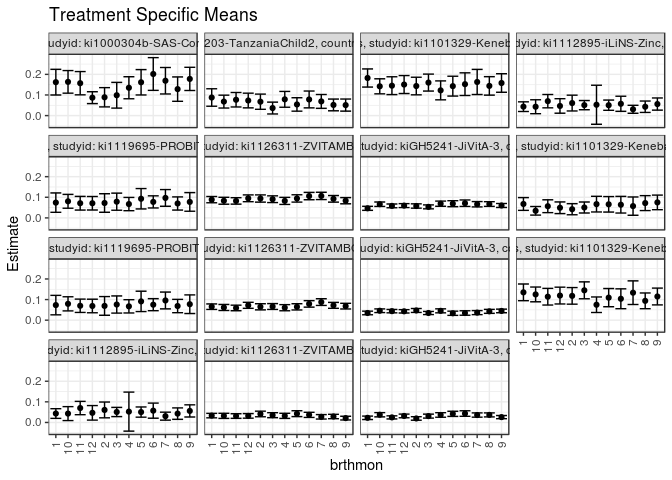

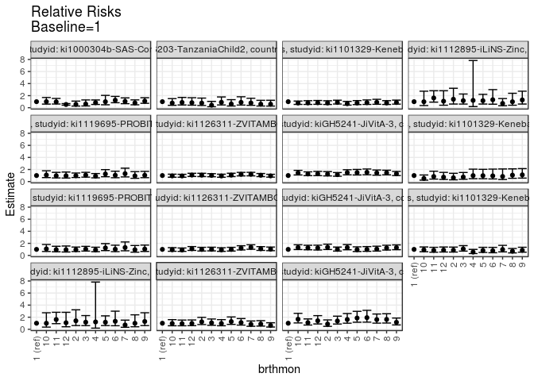

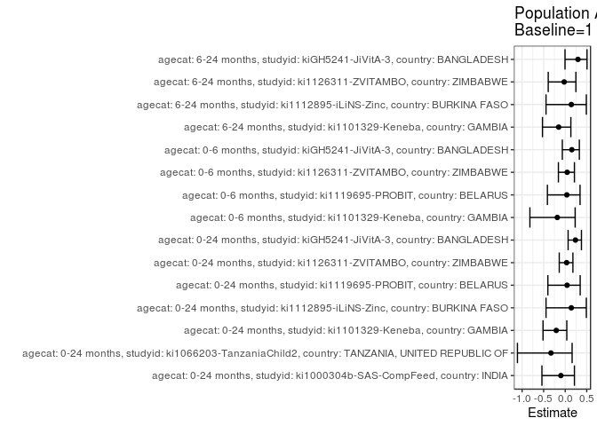

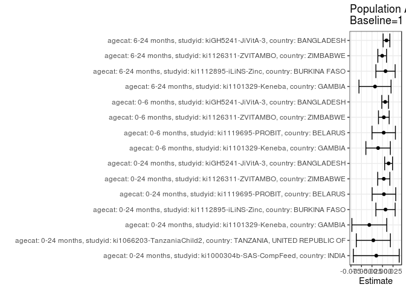

## Results Table

### Parameter: TSM

| agecat | studyid | country | intervention_level | baseline_level | estimate | ci_lower | ci_upper |
| --- | --- | --- | --- | --- | --- | --- | --- |
| 0-24 months | ki1000304b-SAS-CompFeed | INDIA | 1 | NA | 0.1621622 | 0.0998823 | 0.2244420 |
| 0-24 months | ki1000304b-SAS-CompFeed | INDIA | 2 | NA | 0.0888889 | 0.0421925 | 0.1355853 |
| 0-24 months | ki1000304b-SAS-CompFeed | INDIA | 3 | NA | 0.0987654 | 0.0364389 | 0.1610919 |
| 0-24 months | ki1000304b-SAS-CompFeed | INDIA | 4 | NA | 0.1351351 | 0.0816900 | 0.1885803 |
| 0-24 months | ki1000304b-SAS-CompFeed | INDIA | 5 | NA | 0.1616162 | 0.1000143 | 0.2232181 |
| 0-24 months | ki1000304b-SAS-CompFeed | INDIA | 6 | NA | 0.2018349 | 0.1224321 | 0.2812376 |
| 0-24 months | ki1000304b-SAS-CompFeed | INDIA | 7 | NA | 0.1691176 | 0.1048189 | 0.2334164 |
| 0-24 months | ki1000304b-SAS-CompFeed | INDIA | 8 | NA | 0.1284916 | 0.0694079 | 0.1875754 |
| 0-24 months | ki1000304b-SAS-CompFeed | INDIA | 9 | NA | 0.1780105 | 0.1217106 | 0.2343103 |
| 0-24 months | ki1000304b-SAS-CompFeed | INDIA | 10 | NA | 0.1636364 | 0.1087663 | 0.2185064 |
| 0-24 months | ki1000304b-SAS-CompFeed | INDIA | 11 | NA | 0.1571429 | 0.1007371 | 0.2135487 |
| 0-24 months | ki1000304b-SAS-CompFeed | INDIA | 12 | NA | 0.0869565 | 0.0581316 | 0.1157815 |
| 0-24 months | ki1066203-TanzaniaChild2 | TANZANIA, UNITED REPUBLIC OF | 1 | NA | 0.0877193 | 0.0453108 | 0.1301278 |
| 0-24 months | ki1066203-TanzaniaChild2 | TANZANIA, UNITED REPUBLIC OF | 2 | NA | 0.0674157 | 0.0305729 | 0.1042586 |
| 0-24 months | ki1066203-TanzaniaChild2 | TANZANIA, UNITED REPUBLIC OF | 3 | NA | 0.0365854 | 0.0078460 | 0.0653247 |
| 0-24 months | ki1066203-TanzaniaChild2 | TANZANIA, UNITED REPUBLIC OF | 4 | NA | 0.0789474 | 0.0405967 | 0.1172980 |
| 0-24 months | ki1066203-TanzaniaChild2 | TANZANIA, UNITED REPUBLIC OF | 5 | NA | 0.0540541 | 0.0214629 | 0.0866452 |
| 0-24 months | ki1066203-TanzaniaChild2 | TANZANIA, UNITED REPUBLIC OF | 6 | NA | 0.0783133 | 0.0374348 | 0.1191917 |
| 0-24 months | ki1066203-TanzaniaChild2 | TANZANIA, UNITED REPUBLIC OF | 7 | NA | 0.0688073 | 0.0351990 | 0.1024157 |
| 0-24 months | ki1066203-TanzaniaChild2 | TANZANIA, UNITED REPUBLIC OF | 8 | NA | 0.0517241 | 0.0232199 | 0.0802283 |
| 0-24 months | ki1066203-TanzaniaChild2 | TANZANIA, UNITED REPUBLIC OF | 9 | NA | 0.0509259 | 0.0216014 | 0.0802505 |
| 0-24 months | ki1066203-TanzaniaChild2 | TANZANIA, UNITED REPUBLIC OF | 10 | NA | 0.0680000 | 0.0367873 | 0.0992127 |
| 0-24 months | ki1066203-TanzaniaChild2 | TANZANIA, UNITED REPUBLIC OF | 11 | NA | 0.0769231 | 0.0417840 | 0.1120621 |
| 0-24 months | ki1066203-TanzaniaChild2 | TANZANIA, UNITED REPUBLIC OF | 12 | NA | 0.0731707 | 0.0375149 | 0.1088265 |
| 0-24 months | ki1101329-Keneba | GAMBIA | 1 | NA | 0.1824324 | 0.1384287 | 0.2264362 |
| 0-24 months | ki1101329-Keneba | GAMBIA | 2 | NA | 0.1434109 | 0.1006359 | 0.1861858 |
| 0-24 months | ki1101329-Keneba | GAMBIA | 3 | NA | 0.1601307 | 0.1190342 | 0.2012272 |
| 0-24 months | ki1101329-Keneba | GAMBIA | 4 | NA | 0.1224490 | 0.0765495 | 0.1683485 |
| 0-24 months | ki1101329-Keneba | GAMBIA | 5 | NA | 0.1428571 | 0.0947120 | 0.1910022 |
| 0-24 months | ki1101329-Keneba | GAMBIA | 6 | NA | 0.1524390 | 0.0974173 | 0.2074607 |

[output cut: 150 more lines]

### Parameter: E(Y)

| agecat | studyid | country | intervention_level | baseline_level | estimate | ci_lower | ci_upper |
| --- | --- | --- | --- | --- | --- | --- | --- |
| 0-24 months | ki1000304b-SAS-CompFeed | INDIA | NA | NA | 0.1473893 | 0.1184132 | 0.1763654 |
| 0-24 months | ki1066203-TanzaniaChild2 | TANZANIA, UNITED REPUBLIC OF | NA | NA | 0.0659432 | 0.0560037 | 0.0758828 |
| 0-24 months | ki1101329-Keneba | GAMBIA | NA | NA | 0.1510791 | 0.1380852 | 0.1640731 |
| 0-24 months | ki1112895-iLiNS-Zinc | BURKINA FASO | NA | NA | 0.0505205 | 0.0383088 | 0.0627322 |
| 0-24 months | ki1119695-PROBIT | BELARUS | NA | NA | 0.0774648 | 0.0450418 | 0.1098878 |
| 0-24 months | ki1126311-ZVITAMBO | ZIMBABWE | NA | NA | 0.0915417 | 0.0867542 | 0.0963292 |
| 0-24 months | kiGH5241-JiVitA-3 | BANGLADESH | NA | NA | 0.0609421 | 0.0574707 | 0.0644136 |
| 0-6 months | ki1101329-Keneba | GAMBIA | NA | NA | 0.0570373 | 0.0478278 | 0.0662468 |
| 0-6 months | ki1119695-PROBIT | BELARUS | NA | NA | 0.0760580 | 0.0435003 | 0.1086157 |
| 0-6 months | ki1126311-ZVITAMBO | ZIMBABWE | NA | NA | 0.0686791 | 0.0644666 | 0.0728917 |
| 0-6 months | kiGH5241-JiVitA-3 | BANGLADESH | NA | NA | 0.0412835 | 0.0383098 | 0.0442573 |
| 6-24 months | ki1101329-Keneba | GAMBIA | NA | NA | 0.1172389 | 0.1051866 | 0.1292911 |
| 6-24 months | ki1112895-iLiNS-Zinc | BURKINA FASO | NA | NA | 0.0505205 | 0.0383088 | 0.0627322 |
| 6-24 months | ki1126311-ZVITAMBO | ZIMBABWE | NA | NA | 0.0325416 | 0.0291786 | 0.0359047 |
| 6-24 months | kiGH5241-JiVitA-3 | BANGLADESH | NA | NA | 0.0319690 | 0.0290813 | 0.0348568 |

### Parameter: RR

| agecat | studyid | country | intervention_level | baseline_level | estimate | ci_lower | ci_upper |
| --- | --- | --- | --- | --- | --- | --- | --- |
| 0-24 months | ki1000304b-SAS-CompFeed | INDIA | 1 | 1 | 1.0000000 | 1.0000000 | 1.0000000 |
| 0-24 months | ki1000304b-SAS-CompFeed | INDIA | 2 | 1 | 0.5481482 | 0.2747140 | 1.0937429 |
| 0-24 months | ki1000304b-SAS-CompFeed | INDIA | 3 | 1 | 0.6090535 | 0.2876798 | 1.2894412 |
| 0-24 months | ki1000304b-SAS-CompFeed | INDIA | 4 | 1 | 0.8333333 | 0.5400637 | 1.2858565 |
| 0-24 months | ki1000304b-SAS-CompFeed | INDIA | 5 | 1 | 0.9966330 | 0.4862095 | 2.0428997 |
| 0-24 months | ki1000304b-SAS-CompFeed | INDIA | 6 | 1 | 1.2446483 | 0.8263132 | 1.8747728 |
| 0-24 months | ki1000304b-SAS-CompFeed | INDIA | 7 | 1 | 1.0428922 | 0.6681305 | 1.6278616 |
| 0-24 months | ki1000304b-SAS-CompFeed | INDIA | 8 | 1 | 0.7923650 | 0.4847086 | 1.2952985 |
| 0-24 months | ki1000304b-SAS-CompFeed | INDIA | 9 | 1 | 1.0977312 | 0.7292891 | 1.6523131 |
| 0-24 months | ki1000304b-SAS-CompFeed | INDIA | 10 | 1 | 1.0090909 | 0.6011482 | 1.6938660 |
| 0-24 months | ki1000304b-SAS-CompFeed | INDIA | 11 | 1 | 0.9690476 | 0.6124283 | 1.5333277 |
| 0-24 months | ki1000304b-SAS-CompFeed | INDIA | 12 | 1 | 0.5362320 | 0.4192877 | 0.6857935 |
| 0-24 months | ki1066203-TanzaniaChild2 | TANZANIA, UNITED REPUBLIC OF | 1 | 1 | 1.0000000 | 1.0000000 | 1.0000000 |
| 0-24 months | ki1066203-TanzaniaChild2 | TANZANIA, UNITED REPUBLIC OF | 2 | 1 | 0.7685393 | 0.3704941 | 1.5942295 |
| 0-24 months | ki1066203-TanzaniaChild2 | TANZANIA, UNITED REPUBLIC OF | 3 | 1 | 0.4170734 | 0.1658146 | 1.0490644 |
| 0-24 months | ki1066203-TanzaniaChild2 | TANZANIA, UNITED REPUBLIC OF | 4 | 1 | 0.9000000 | 0.4535214 | 1.7860236 |
| 0-24 months | ki1066203-TanzaniaChild2 | TANZANIA, UNITED REPUBLIC OF | 5 | 1 | 0.6162162 | 0.2845104 | 1.3346520 |
| 0-24 months | ki1066203-TanzaniaChild2 | TANZANIA, UNITED REPUBLIC OF | 6 | 1 | 0.8927711 | 0.4382780 | 1.8185724 |
| 0-24 months | ki1066203-TanzaniaChild2 | TANZANIA, UNITED REPUBLIC OF | 7 | 1 | 0.7844037 | 0.3945236 | 1.5595751 |
| 0-24 months | ki1066203-TanzaniaChild2 | TANZANIA, UNITED REPUBLIC OF | 8 | 1 | 0.5896552 | 0.2832835 | 1.2273683 |
| 0-24 months | ki1066203-TanzaniaChild2 | TANZANIA, UNITED REPUBLIC OF | 9 | 1 | 0.5805556 | 0.2737229 | 1.2313358 |
| 0-24 months | ki1066203-TanzaniaChild2 | TANZANIA, UNITED REPUBLIC OF | 10 | 1 | 0.7752000 | 0.3980081 | 1.5098562 |
| 0-24 months | ki1066203-TanzaniaChild2 | TANZANIA, UNITED REPUBLIC OF | 11 | 1 | 0.8769231 | 0.4509179 | 1.7053971 |
| 0-24 months | ki1066203-TanzaniaChild2 | TANZANIA, UNITED REPUBLIC OF | 12 | 1 | 0.8341463 | 0.4198837 | 1.6571259 |
| 0-24 months | ki1101329-Keneba | GAMBIA | 1 | 1 | 1.0000000 | 1.0000000 | 1.0000000 |
| 0-24 months | ki1101329-Keneba | GAMBIA | 2 | 1 | 0.7861039 | 0.5356574 | 1.1536466 |
| 0-24 months | ki1101329-Keneba | GAMBIA | 3 | 1 | 0.8777536 | 0.6171821 | 1.2483371 |
| 0-24 months | ki1101329-Keneba | GAMBIA | 4 | 1 | 0.6712018 | 0.4298015 | 1.0481859 |
| 0-24 months | ki1101329-Keneba | GAMBIA | 5 | 1 | 0.7830688 | 0.5173820 | 1.1851914 |
| 0-24 months | ki1101329-Keneba | GAMBIA | 6 | 1 | 0.8355917 | 0.5413255 | 1.2898219 |

[output cut: 150 more lines]

### Parameter: PAR

| agecat | studyid | country | intervention_level | baseline_level | estimate | ci_lower | ci_upper |
| --- | --- | --- | --- | --- | --- | --- | --- |
| 0-24 months | ki1000304b-SAS-CompFeed | INDIA | 1 | NA | -0.0147729 | -0.0692896 | 0.0397439 |
| 0-24 months | ki1066203-TanzaniaChild2 | TANZANIA, UNITED REPUBLIC OF | 1 | NA | -0.0217761 | -0.0622799 | 0.0187278 |
| 0-24 months | ki1101329-Keneba | GAMBIA | 1 | NA | -0.0313533 | -0.0727352 | 0.0100287 |
| 0-24 months | ki1112895-iLiNS-Zinc | BURKINA FASO | 1 | NA | 0.0071769 | -0.0157387 | 0.0300924 |
| 0-24 months | ki1119695-PROBIT | BELARUS | 1 | NA | 0.0033907 | -0.0246369 | 0.0314184 |
| 0-24 months | ki1126311-ZVITAMBO | ZIMBABWE | 1 | NA | 0.0030659 | -0.0113847 | 0.0175165 |
| 0-24 months | kiGH5241-JiVitA-3 | BANGLADESH | 1 | NA | 0.0145050 | 0.0051385 | 0.0238715 |
| 0-6 months | ki1101329-Keneba | GAMBIA | 1 | NA | -0.0104230 | -0.0395053 | 0.0186594 |
| 0-6 months | ki1119695-PROBIT | BELARUS | 1 | NA | 0.0028873 | -0.0249326 | 0.0307072 |
| 0-6 months | ki1126311-ZVITAMBO | ZIMBABWE | 1 | NA | 0.0031671 | -0.0095167 | 0.0158509 |
| 0-6 months | kiGH5241-JiVitA-3 | BANGLADESH | 1 | NA | 0.0063438 | -0.0017107 | 0.0143983 |
| 6-24 months | ki1101329-Keneba | GAMBIA | 1 | NA | -0.0177976 | -0.0559491 | 0.0203539 |
| 6-24 months | ki1112895-iLiNS-Zinc | BURKINA FASO | 1 | NA | 0.0071769 | -0.0157387 | 0.0300924 |
| 6-24 months | ki1126311-ZVITAMBO | ZIMBABWE | 1 | NA | -0.0007600 | -0.0110487 | 0.0095286 |
| 6-24 months | kiGH5241-JiVitA-3 | BANGLADESH | 1 | NA | 0.0094726 | 0.0014704 | 0.0174749 |

### Parameter: PAF

| agecat | studyid | country | intervention_level | baseline_level | estimate | ci_lower | ci_upper |
| --- | --- | --- | --- | --- | --- | --- | --- |
| 0-24 months | ki1000304b-SAS-CompFeed | INDIA | 1 | NA | -0.1002303 | -0.5400317 | 0.2139729 |
| 0-24 months | ki1066203-TanzaniaChild2 | TANZANIA, UNITED REPUBLIC OF | 1 | NA | -0.3302243 | -1.1082504 | 0.1606800 |
| 0-24 months | ki1101329-Keneba | GAMBIA | 1 | NA | -0.2075290 | -0.5145763 | 0.0372712 |
| 0-24 months | ki1112895-iLiNS-Zinc | BURKINA FASO | 1 | NA | 0.1420584 | -0.4448819 | 0.4905716 |
| 0-24 months | ki1119695-PROBIT | BELARUS | 1 | NA | 0.0437710 | -0.4021647 | 0.3478842 |
| 0-24 months | ki1126311-ZVITAMBO | ZIMBABWE | 1 | NA | 0.0334916 | -0.1379804 | 0.1791261 |
| 0-24 months | kiGH5241-JiVitA-3 | BANGLADESH | 1 | NA | 0.2380124 | 0.0677452 | 0.3771820 |
| 0-6 months | ki1101329-Keneba | GAMBIA | 1 | NA | -0.1827395 | -0.8190552 | 0.2309894 |
| 0-6 months | ki1119695-PROBIT | BELARUS | 1 | NA | 0.0379615 | -0.4127545 | 0.3448840 |
| 0-6 months | ki1126311-ZVITAMBO | ZIMBABWE | 1 | NA | 0.0461143 | -0.1576347 | 0.2140025 |
| 0-6 months | kiGH5241-JiVitA-3 | BANGLADESH | 1 | NA | 0.1536639 | -0.0665153 | 0.3283877 |
| 6-24 months | ki1101329-Keneba | GAMBIA | 1 | NA | -0.1518066 | -0.5275014 | 0.1314846 |
| 6-24 months | ki1112895-iLiNS-Zinc | BURKINA FASO | 1 | NA | 0.1420584 | -0.4448819 | 0.4905716 |
| 6-24 months | ki1126311-ZVITAMBO | ZIMBABWE | 1 | NA | -0.0233549 | -0.3937968 | 0.2486314 |
| 6-24 months | kiGH5241-JiVitA-3 | BANGLADESH | 1 | NA | 0.2963070 | -0.0039963 | 0.5067872 |